# Intro to CDA in R: Models for Dichotomous Variables

01/12/2019

### Projects

- Reason what the measures you do mean in terms of the concepts we are dealing with. What is the “distance” between one and the other?
- what about causality?
- make sure you define well what the variables mean, how to operationalize them
- I don’t know much about the subject matter of the different projects, but as we progress in the course it would be wise to consider more the “statistical” or methodological challenges
- There might be other students working on a similar project
- Send comments on research questions this afternoon

### Past quiz

- Remarks on past quiz

## Previously on CDA

## Probability theory

- Conditional expectation function \[\mathbb{E}[y_i|xi]=\beta_0 + \beta_1 \times x_{i,1} + \beta_2 \times x_{i,2} + ... + \beta_p \times x_{i,p}\]
- Conditional probability function \[\mathbb{P}(y_i|x_i)=f(y_i|x_i;\theta)\]
- Marginal probability effects \(\frac{\partial \mathbb{P}(y_i|x_i)}{\partial x_{p,i}}\) (but there are as many MPE as there are categories in the variable \(x_{p,i}\))

## Conditional probability models

1. Select a simple univariate probability function \(P(Y = y) = f(y; θ)\)
2. Express the parameter \(\theta\) as a function of \(X\) to obtain a conditional probability model \(f(y|x; \theta)\)

Where \(f(y; \theta)\) should have the same support as the observed variable

## Maximum Likelihood Estimation

## Basic idea

- Find the set of parameter estimates \(\hat{\theta}\) such that the likelihood is maximized
- \(L_n(\theta) = L_n(\theta|y) = f_n(y;\theta)\)
- where \(f_n(y;\theta)\) product of univariate density functions
- Very general principle
- Applies whenever the joint probability distribution can be written explicitely

## Properties of the Maximum Likelihood Estimator

1. consistent
2. asymptotically normal
3. efficient

## Dichotomous variables

- Binary indicators
- Which models do you know already fit this?
- Widely used in empirical applications
- Texts, ordinal, nominal and even metric variables can be converted into binary variables
- Binary response models can be distinguished by the way they parameterize \(\pi_i\) in terms of \(x_i\)

## Outline

- pros and cons of these models
- how to interpret parameters correctly
- why estimation (using MLE) may fail
- goodness-of-fit measures

## Linear Probability Model I

- Assumption of exogeneity: \(\mathbb{E}[u_i|x_i]=0\)
- Marginal effect of \(x_j\) \[ \frac{\partial \mathbb{E}[y_i|xi]}{\partial x_{j,i}} = \frac{\partial \mathbb{P}(y_i=1|x_i)}{\partial x_{p,i}}=\beta_j\]
- This is constant in the case of the linear model!

## Linear Probability Model II

- But! we know has to fulfill the condition that \(0 \le x_{(i)}'\beta \le 1\)
- Heteroskedastic: \(Var(u_i|x_i)=x_i'\beta(1-x_i'\beta)\)
- If robust standard errors (or MLE) then linear model is a useful exploratory tool!
- direct estimation of marginal effects and important variables

## Linear Probability Model III

- \(R^2\)
- Statistical significance tests
- Warning: statistical tests do not mean anything [this!](https://amstat.tandfonline.com/doi/full/10.1080/00031305.2019.1583913)

## Nonlinear models

## The approach

- We have two types of outcomes \(Y \in \{0,1\}\) (e.g. success or failure)
- And we are interested in \(\mathbb{P}(Y=1| x_i)=\pi_i\)
- The standard models used in practice have in common that \(\pi_i\) is derived as a monotonic transformation of a linear index function
- \(\pi_i=G(x_i'\beta)\) with \(x_i'\beta = \beta_0 + \beta_1 \times x_{i,1} + \beta_2 \times x_{i,2} + ... + \beta_p \times x_{i,p}\)

## The approach II

- So what do we need about \(G(.)\), if we know we want to model a response variable with valies in \(\in \{0,1\}\)?
- \(0 \le G(x_i'\beta) \le 1\)
- It follows that \(\frac{\partial \pi_i}{\partial x_{il}}=g(x_i'\beta)\beta_l\) are not constant (depend on the values of covariates)
- Even though \(G^{-1}(\pi_i)=x_i'\beta\), we can still include interactions, quadratic terms, and all kinds of transformations of the varibles in \(x_i'\)

## The approach III

- Let \(z=x_{(i)}'\beta\)
- In the LPM: \(G(z) = z\) (or the identity function)
- Identifiability of the models is based on restrictions placed on variance

## Probit model

- \(G(z) = \phi(z) = \int_{-\infty}^{z} \frac{1}{\sqrt{2\pi}}e^{-x^2/2}dx\)
- which is the CDF of a standardized normal variable (\(N(0,1)\))
- imposing no restriction on the linear index \(x_i'\beta\), and maps them onto the unit interval (\(\in(0,1)\))
- Nice interpretation using latent variables (especially for microeconomists)
- probability depends on two parameters, \(\beta\) and \(\sigma\). Unfortunately, this is one too many
- Restriction \(Var(\epsilon_i)=1\)
- interpretation should focus on what we originally intended to model, namely the conditional probabilities of observing the binary outcomes.

## Logit model

- Often referred to as logistic regression
- Choice of \(G(z)=\Lambda(z) = \frac{e^z}{1+e^z}\)
- the cumulative density function of the (standard) logistic distribution
- Restriction \(Var(\epsilon_i)=\pi^2/3\)
- logit and probit turn out to be very similar
- choice between the two makes little difference in practice

## Comparison I

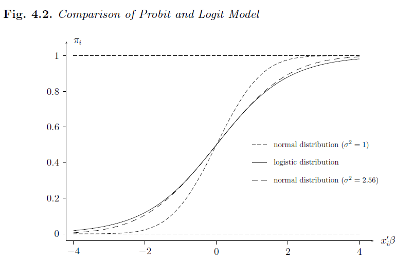

- Taken from Winkelmann p. 102

## Comparison II

- Slope is flatter in the logistic than probit
- Higher variance in logistic than probit
- Coefficients of both models need to be rescaled to compare them
- simply multiplying the probit coefficients by \(1.6\), we get similar coefficients as logit

## Interpretation: Marginal effects I

- In practice, one often wants to make statements about the expected effect, or the effect for a “typical” person
- These vary across individuals (dependent on the levels of explanatory variables \(x_{(i)}\))
- Average marginal effects

\[\frac{1}{N} \sum_{i=1}^N \frac{\partial \mathbb{P}(y_i=1|x_i)}{\partial x_{p,i}}=\beta_j \frac{1}{N} \sum_{i=1}^N g(x_{(i)}'\beta)\]

## Interpretation: Marginal effects II

- Marginal effects evaluated at the average of the \(x_{(i)}\) \[\frac{\partial \mathbb{P}(y_i=1|x_i)}{\partial x_{p,i}} \rvert_{x_{(i)}=\bar{x}_{(.)}} = g(\bar{x}_{(.)}\beta_j)\] where \(\bar{x}_{(.)}=\frac{1}{N}\sum_{i=1}^Nx_{(i)}\)
- \(\mathbb{E}[g(x_{(i)}'\beta)] \ne g(\mathbb{E}[x_{(i)}'\beta])\)
- Interpret as: change in the success probability due to a change in the l-th regressor by the amount
- Problem of perfect predictors

## Interpretation: Margina effects III

- The sign of the marginal effect is equal to the sign of \(\beta_l\)
- The effect is largest for \(x_{(i)}'\beta = 0\)
- The effect varies among individuals

## Odds ratios

- Only due to the structure of the logit model
- Odds: \(\frac{P(y_i=1|x_i)}{P(y_i=0|x_i)} = \frac{\pi_i}{1-\pi_1} = exp(x_{(i)}'\beta)\)
- Factor change in odds \[\frac{exp(x_{il}'\beta_l + \Delta x_{il}'\beta_l)}{exp(x_{il}'\beta_l)}=exp(\Delta x_{il}'\beta_l)\]
- if \(\Delta x_{il}=1\), then \(exp(\beta_l)\) is the **odds ratio**
- Relative change in odds: \(100 \times [exp(\beta_l)-1]\)

## Back to R

## Goodness-of-fit

- McFadden pseudo \(R^2\)
- Contingency Table for Binary Predictions
- Two types of errors: which ones?
- ROC and the AUC

## Next on CDA

- For binary variables: log-linked binomial model
- Goodness-of-fit measures
- Look at some plot functions for the predicted probabilities
- Multinomial models

### To do

- Read your data in R: start documenting your problems (Rmarkdown)
- Look at your main variables of analysis and do basic descriptives

### Read

- Chapter 5 of Analysis of Microdata (by Winkelmann)